# wrangle_act slides

## Gather 收集数据

```python
import pandas as pd
import numpy as np
import requests
import json
import matplotlib.pyplot as plt
import seaborn as sns
sns.set_style('darkgrid')
```

```python
#gather data by loading csv file

dogs_rate = pd.read_csv('twitter-archive-enhanced.csv')
```

```python
dogs_rate.head()
```

|  | tweet_id | in_reply_to_status_id | in_reply_to_user_id | timestamp | source | text | retweeted_status_id | retweeted_status_user_id | retweeted_status_timestamp | expanded_urls | rating_numerator | rating_denominator | name | doggo | floofer | pupper | puppo |
| --- | --- | --- | --- | --- | --- | --- | --- | --- | --- | --- | --- | --- | --- | --- | --- | --- | --- |
| 0 | 892420643555336193 | NaN | NaN | 2017-08-01 16:23:56 +0000 | <a href="http://twitter.com/download/iphone" r... | This is Phineas. He's a mystical boy. Only eve... | NaN | NaN | NaN | https://twitter.com/dog_rates/status/892420643... | 13 | 10 | Phineas | None | None | None | None |
| 1 | 892177421306343426 | NaN | NaN | 2017-08-01 00:17:27 +0000 | <a href="http://twitter.com/download/iphone" r... | This is Tilly. She's just checking pup on you.... | NaN | NaN | NaN | https://twitter.com/dog_rates/status/892177421... | 13 | 10 | Tilly | None | None | None | None |
| 2 | 891815181378084864 | NaN | NaN | 2017-07-31 00:18:03 +0000 | <a href="http://twitter.com/download/iphone" r... | This is Archie. He is a rare Norwegian Pouncin... | NaN | NaN | NaN | https://twitter.com/dog_rates/status/891815181... | 12 | 10 | Archie | None | None | None | None |
| 3 | 891689557279858688 | NaN | NaN | 2017-07-30 15:58:51 +0000 | <a href="http://twitter.com/download/iphone" r... | This is Darla. She commenced a snooze mid meal... | NaN | NaN | NaN | https://twitter.com/dog_rates/status/891689557... | 13 | 10 | Darla | None | None | None | None |
| 4 | 891327558926688256 | NaN | NaN | 2017-07-29 16:00:24 +0000 | <a href="http://twitter.com/download/iphone" r... | This is Franklin. He would like you to stop ca... | NaN | NaN | NaN | https://twitter.com/dog_rates/status/891327558... | 12 | 10 | Franklin | None | None | None | None |

```python
#gather data from internet

# Use requests library to download tsv file from a website
url="https://raw.githubusercontent.com/udacity/new-dand-advanced-china/master/%E6%95%B0%E6%8D%AE%E6%B8%85%E6%B4%97/WeRateDogs%E9%A1%B9%E7%9B%AE/image-predictions.tsv"
response = requests.get(url)

with open('image_predictions.tsv', 'wb') as file:
    file.write(response.content)

# Read in tsv file as a Pandas DataFrame
image = pd.read_csv('image_predictions.tsv', sep='\t')
```

```python
# List of dictionaries to build file by file and later convert to a DataFrame
tweet_list = []

with open ('tweet_json.txt','r')as f:
    for line in f :
        json_line= json.loads(line)

        tweet_list.append({'tweet_id':json_line['id'],
                           'retweet_count':json_line['retweet_count'],
                           'favorite_count':json_line['favorite_count']})
tweet_df = pd.DataFrame(tweet_list, columns=['tweet_id','retweet_count','favorite_count'])
```

## Access 评估数据

```python
#access dogs_rate table
dogs_rate.head()
```

|  | tweet_id | in_reply_to_status_id | in_reply_to_user_id | timestamp | source | text | retweeted_status_id | retweeted_status_user_id | retweeted_status_timestamp | expanded_urls | rating_numerator | rating_denominator | name | doggo | floofer | pupper | puppo |
| --- | --- | --- | --- | --- | --- | --- | --- | --- | --- | --- | --- | --- | --- | --- | --- | --- | --- |
| 0 | 892420643555336193 | NaN | NaN | 2017-08-01 16:23:56 +0000 | <a href="http://twitter.com/download/iphone" r... | This is Phineas. He's a mystical boy. Only eve... | NaN | NaN | NaN | https://twitter.com/dog_rates/status/892420643... | 13 | 10 | Phineas | None | None | None | None |
| 1 | 892177421306343426 | NaN | NaN | 2017-08-01 00:17:27 +0000 | <a href="http://twitter.com/download/iphone" r... | This is Tilly. She's just checking pup on you.... | NaN | NaN | NaN | https://twitter.com/dog_rates/status/892177421... | 13 | 10 | Tilly | None | None | None | None |
| 2 | 891815181378084864 | NaN | NaN | 2017-07-31 00:18:03 +0000 | <a href="http://twitter.com/download/iphone" r... | This is Archie. He is a rare Norwegian Pouncin... | NaN | NaN | NaN | https://twitter.com/dog_rates/status/891815181... | 12 | 10 | Archie | None | None | None | None |
| 3 | 891689557279858688 | NaN | NaN | 2017-07-30 15:58:51 +0000 | <a href="http://twitter.com/download/iphone" r... | This is Darla. She commenced a snooze mid meal... | NaN | NaN | NaN | https://twitter.com/dog_rates/status/891689557... | 13 | 10 | Darla | None | None | None | None |
| 4 | 891327558926688256 | NaN | NaN | 2017-07-29 16:00:24 +0000 | <a href="http://twitter.com/download/iphone" r... | This is Franklin. He would like you to stop ca... | NaN | NaN | NaN | https://twitter.com/dog_rates/status/891327558... | 12 | 10 | Franklin | None | None | None | None |

```python
dogs_rate.tail()
```

|  | tweet_id | in_reply_to_status_id | in_reply_to_user_id | timestamp | source | text | retweeted_status_id | retweeted_status_user_id | retweeted_status_timestamp | expanded_urls | rating_numerator | rating_denominator | name | doggo | floofer | pupper | puppo |
| --- | --- | --- | --- | --- | --- | --- | --- | --- | --- | --- | --- | --- | --- | --- | --- | --- | --- |
| 2351 | 666049248165822465 | NaN | NaN | 2015-11-16 00:24:50 +0000 | <a href="http://twitter.com/download/iphone" r... | Here we have a 1949 1st generation vulpix. Enj... | NaN | NaN | NaN | https://twitter.com/dog_rates/status/666049248... | 5 | 10 | None | None | None | None | None |
| 2352 | 666044226329800704 | NaN | NaN | 2015-11-16 00:04:52 +0000 | <a href="http://twitter.com/download/iphone" r... | This is a purebred Piers Morgan. Loves to Netf... | NaN | NaN | NaN | https://twitter.com/dog_rates/status/666044226... | 6 | 10 | a | None | None | None | None |
| 2353 | 666033412701032449 | NaN | NaN | 2015-11-15 23:21:54 +0000 | <a href="http://twitter.com/download/iphone" r... | Here is a very happy pup. Big fan of well-main... | NaN | NaN | NaN | https://twitter.com/dog_rates/status/666033412... | 9 | 10 | a | None | None | None | None |
| 2354 | 666029285002620928 | NaN | NaN | 2015-11-15 23:05:30 +0000 | <a href="http://twitter.com/download/iphone" r... | This is a western brown Mitsubishi terrier. Up... | NaN | NaN | NaN | https://twitter.com/dog_rates/status/666029285... | 7 | 10 | a | None | None | None | None |
| 2355 | 666020888022790149 | NaN | NaN | 2015-11-15 22:32:08 +0000 | <a href="http://twitter.com/download/iphone" r... | Here we have a Japanese Irish Setter. Lost eye... | NaN | NaN | NaN | https://twitter.com/dog_rates/status/666020888... | 8 | 10 | None | None | None | None | None |

```python
dogs_rate.sample(5)
```

|  | tweet_id | in_reply_to_status_id | in_reply_to_user_id | timestamp | source | text | retweeted_status_id | retweeted_status_user_id | retweeted_status_timestamp | expanded_urls | rating_numerator | rating_denominator | name | doggo | floofer | pupper | puppo |
| --- | --- | --- | --- | --- | --- | --- | --- | --- | --- | --- | --- | --- | --- | --- | --- | --- | --- |
| 1865 | 675354435921575936 | NaN | NaN | 2015-12-11 16:40:19 +0000 | <a href="http://twitter.com" rel="nofollow">Tw... | Everyone needs to watch this. 13/10 https://t.... | NaN | NaN | NaN | https://twitter.com/dog_rates/status/675354435... | 13 | 10 | None | None | None | None | None |
| 18 | 888554962724278272 | NaN | NaN | 2017-07-22 00:23:06 +0000 | <a href="http://twitter.com/download/iphone" r... | This is Ralphus. He's powering up. Attempting ... | NaN | NaN | NaN | https://twitter.com/dog_rates/status/888554962... | 13 | 10 | Ralphus | None | None | None | None |
| 981 | 749417653287129088 | NaN | NaN | 2016-07-03 01:41:06 +0000 | <a href="http://twitter.com/download/iphone" r... | This is Finn. He's the most unphotogenic puppe... | NaN | NaN | NaN | https://twitter.com/dog_rates/status/749417653... | 11 | 10 | Finn | None | None | pupper | None |
| 656 | 791780927877898241 | NaN | NaN | 2016-10-27 23:17:38 +0000 | <a href="http://twitter.com/download/iphone" r... | RT @dog_rates: This is Maddie. She gets some w... | 7.467577e+17 | 4.196984e+09 | 2016-06-25 17:31:25 +0000 | https://vine.co/v/5BYq6hmrEI3,https://vine.co/... | 11 | 10 | Maddie | None | None | None | None |
| 1000 | 747963614829678593 | NaN | NaN | 2016-06-29 01:23:16 +0000 | <a href="http://twitter.com/download/iphone" r... | PUPPER NOOOOO BEHIND YOUUU 10/10 pls keep this... | NaN | NaN | NaN | https://twitter.com/dog_rates/status/747963614... | 10 | 10 | None | None | None | pupper | None |

```python
dogs_rate.source.value_counts()
```

```
<a href="http://twitter.com/download/iphone" rel="nofollow">Twitter for iPhone</a>     2221
<a href="http://vine.co" rel="nofollow">Vine - Make a Scene</a>                          91
<a href="http://twitter.com" rel="nofollow">Twitter Web Client</a>                       33
<a href="https://about.twitter.com/products/tweetdeck" rel="nofollow">TweetDeck</a>      11
Name: source, dtype: int64
```

```python
dogs_rate.name.value_counts()
```

```
None         745
a             55
Charlie       12
Oliver        11
Lucy          11
Cooper        11
Lola          10
Penny         10
Tucker        10
Winston        9
Bo             9
Sadie          8
the            8
Bailey         7
Toby           7
an             7
Buddy          7
Daisy          7
Rusty          6
Jack           6
Bella          6
Leo            6
Stanley        6
Koda           6
Milo           6
Dave           6
Scout          6
Oscar          6
Jax            6
Sammy          5
            ...
Rupert         1
Mutt           1
Vixen          1
Bloo           1
Lulu           1
Erik           1
Fletcher       1
Bruno          1
Siba           1
Scruffers      1
Mark           1
Mabel          1
Benny          1
Hermione       1
Fwed           1
Batdog         1
Shnuggles      1
Rontu          1
Goliath        1
Herb           1
Ashleigh       1
JD             1
Kanu           1
Bubba          1
Chaz           1
Divine         1
Brat           1
Kaia           1
Oreo           1
Boots          1
Name: name, Length: 957, dtype: int64
```

```python
dogs_rate.info()
```

```
<class 'pandas.core.frame.DataFrame'>
RangeIndex: 2356 entries, 0 to 2355
Data columns (total 17 columns):
tweet_id                      2356 non-null int64
in_reply_to_status_id         78 non-null float64
in_reply_to_user_id           78 non-null float64
timestamp                     2356 non-null object
source                        2356 non-null object
text                          2356 non-null object
retweeted_status_id           181 non-null float64
retweeted_status_user_id      181 non-null float64
retweeted_status_timestamp    181 non-null object
expanded_urls                 2297 non-null object
rating_numerator              2356 non-null int64
rating_denominator            2356 non-null int64
name                          2356 non-null object
doggo                         2356 non-null object
floofer                       2356 non-null object
pupper                        2356 non-null object
puppo                         2356 non-null object
dtypes: float64(4), int64(3), object(10)
memory usage: 313.0+ KB
```

```python
dogs_rate.expanded_urls.isnull().sum()
```

```
59
```

```python
dogs_rate.rating_numerator.value_counts()
```

```
12      558
11      464
10      461
13      351
9       158
8       102
7        55
14       54
5        37
6        32
3        19
4        17
1         9
2         9
420       2
```

[output cut: 26 more lines]

```python
dogs_rate.rating_denominator.value_counts()
```

```
10     2333
11        3
50        3
80        2
20        2
2         1
16        1
40        1
70        1
15        1
90        1
110       1
120       1
130       1
150       1
170       1
7         1
0         1
Name: rating_denominator, dtype: int64
```

```python
dogs_rate.query("rating_denominator == 0")
```

|  | tweet_id | in_reply_to_status_id | in_reply_to_user_id | timestamp | source | text | retweeted_status_id | retweeted_status_user_id | retweeted_status_timestamp | expanded_urls | rating_numerator | rating_denominator | name | doggo | floofer | pupper | puppo |
| --- | --- | --- | --- | --- | --- | --- | --- | --- | --- | --- | --- | --- | --- | --- | --- | --- | --- |
| 313 | 835246439529840640 | 8.352460e+17 | 26259576.0 | 2017-02-24 21:54:03 +0000 | <a href="http://twitter.com/download/iphone" r... | @jonnysun @Lin_Manuel ok jomny I know you're e... | NaN | NaN | NaN | NaN | 960 | 0 | None | None | None | None | None |

```python
dogs_rate.query("rating_denominator == 2")
```

|  | tweet_id | in_reply_to_status_id | in_reply_to_user_id | timestamp | source | text | retweeted_status_id | retweeted_status_user_id | retweeted_status_timestamp | expanded_urls | rating_numerator | rating_denominator | name | doggo | floofer | pupper | puppo |
| --- | --- | --- | --- | --- | --- | --- | --- | --- | --- | --- | --- | --- | --- | --- | --- | --- | --- |
| 2335 | 666287406224695296 | NaN | NaN | 2015-11-16 16:11:11 +0000 | <a href="http://twitter.com/download/iphone" r... | This is an Albanian 3 1/2 legged Episcopalian... | NaN | NaN | NaN | https://twitter.com/dog_rates/status/666287406... | 1 | 2 | an | None | None | None | None |

```python
dogs_rate.query("rating_denominator == 7")
```

|  | tweet_id | in_reply_to_status_id | in_reply_to_user_id | timestamp | source | text | retweeted_status_id | retweeted_status_user_id | retweeted_status_timestamp | expanded_urls | rating_numerator | rating_denominator | name | doggo | floofer | pupper | puppo |
| --- | --- | --- | --- | --- | --- | --- | --- | --- | --- | --- | --- | --- | --- | --- | --- | --- | --- |
| 516 | 810984652412424192 | NaN | NaN | 2016-12-19 23:06:23 +0000 | <a href="http://twitter.com/download/iphone" r... | Meet Sam. She smiles 24/7 &amp; secretly aspir... | NaN | NaN | NaN | https://www.gofundme.com/sams-smile,https://tw... | 24 | 7 | Sam | None | None | None | None |

```python
dogs_rate.rating_numerator.describe()
```

```
count    2356.000000
mean       13.126486
std        45.876648
min         0.000000
25%        10.000000
50%        11.000000
75%        12.000000
max      1776.000000
Name: rating_numerator, dtype: float64
```

```python
dogs_rate.query("rating_numerator == 1776 ")
```

|  | tweet_id | in_reply_to_status_id | in_reply_to_user_id | timestamp | source | text | retweeted_status_id | retweeted_status_user_id | retweeted_status_timestamp | expanded_urls | rating_numerator | rating_denominator | name | doggo | floofer | pupper | puppo |
| --- | --- | --- | --- | --- | --- | --- | --- | --- | --- | --- | --- | --- | --- | --- | --- | --- | --- |
| 979 | 749981277374128128 | NaN | NaN | 2016-07-04 15:00:45 +0000 | <a href="https://about.twitter.com/products/tw... | This is Atticus. He's quite simply America af.... | NaN | NaN | NaN | https://twitter.com/dog_rates/status/749981277... | 1776 | 10 | Atticus | None | None | None | None |

```python
dogs_rate.iloc[979]
```

```
tweet_id                                                     749981277374128128
in_reply_to_status_id                                                       NaN
in_reply_to_user_id                                                         NaN
timestamp                                             2016-07-04 15:00:45 +0000
source                        <a href="https://about.twitter.com/products/tw...
text                          This is Atticus. He's quite simply America af....
retweeted_status_id                                                         NaN
retweeted_status_user_id                                                    NaN
retweeted_status_timestamp                                                  NaN
expanded_urls                 https://twitter.com/dog_rates/status/749981277...
rating_numerator                                                           1776
rating_denominator                                                           10
name                                                                    Atticus
doggo                                                                      None
floofer                                                                    None
pupper                                                                     None
puppo                                                                      None
Name: 979, dtype: object
```

```python
dogs_rate.iloc[313]
```

```
tweet_id                                                     835246439529840640
in_reply_to_status_id                                               8.35246e+17
in_reply_to_user_id                                                 2.62596e+07
timestamp                                             2017-02-24 21:54:03 +0000
source                        <a href="http://twitter.com/download/iphone" r...
text                          @jonnysun @Lin_Manuel ok jomny I know you're e...
retweeted_status_id                                                         NaN
retweeted_status_user_id                                                    NaN
retweeted_status_timestamp                                                  NaN
expanded_urls                                                               NaN
rating_numerator                                                            960
rating_denominator                                                            0
name                                                                       None
doggo                                                                      None
floofer                                                                    None
pupper                                                                     None
puppo                                                                      None
Name: 313, dtype: object
```

```python
dogs_rate.iloc[2335]
```

```
tweet_id                                                     666287406224695296
in_reply_to_status_id                                                       NaN
in_reply_to_user_id                                                         NaN
timestamp                                             2015-11-16 16:11:11 +0000
source                        <a href="http://twitter.com/download/iphone" r...
text                          This is an Albanian 3 1/2 legged  Episcopalian...
retweeted_status_id                                                         NaN
retweeted_status_user_id                                                    NaN
retweeted_status_timestamp                                                  NaN
expanded_urls                 https://twitter.com/dog_rates/status/666287406...
rating_numerator                                                              1
rating_denominator                                                            2
name                                                                         an
doggo                                                                      None
floofer                                                                    None
pupper                                                                     None
puppo                                                                      None
Name: 2335, dtype: object
```

```python
dogs_rate.iloc[516]
```

```
tweet_id                                                     810984652412424192
in_reply_to_status_id                                                       NaN
in_reply_to_user_id                                                         NaN
timestamp                                             2016-12-19 23:06:23 +0000
source                        <a href="http://twitter.com/download/iphone" r...
text                          Meet Sam. She smiles 24/7 &amp; secretly aspir...
retweeted_status_id                                                         NaN
retweeted_status_user_id                                                    NaN
retweeted_status_timestamp                                                  NaN
expanded_urls                 https://www.gofundme.com/sams-smile,https://tw...
rating_numerator                                                             24
rating_denominator                                                            7
name                                                                        Sam
doggo                                                                      None
floofer                                                                    None
pupper                                                                     None
puppo                                                                      None
Name: 516, dtype: object
```

```python
#access image table
image.head()
```

|  | tweet_id | jpg_url | img_num | p1 | p1_conf | p1_dog | p2 | p2_conf | p2_dog | p3 | p3_conf | p3_dog |
| --- | --- | --- | --- | --- | --- | --- | --- | --- | --- | --- | --- | --- |
| 0 | 666020888022790149 | https://pbs.twimg.com/media/CT4udn0WwAA0aMy.jpg | 1 | Welsh_springer_spaniel | 0.465074 | True | collie | 0.156665 | True | Shetland_sheepdog | 0.061428 | True |
| 1 | 666029285002620928 | https://pbs.twimg.com/media/CT42GRgUYAA5iDo.jpg | 1 | redbone | 0.506826 | True | miniature_pinscher | 0.074192 | True | Rhodesian_ridgeback | 0.072010 | True |
| 2 | 666033412701032449 | https://pbs.twimg.com/media/CT4521TWwAEvMyu.jpg | 1 | German_shepherd | 0.596461 | True | malinois | 0.138584 | True | bloodhound | 0.116197 | True |
| 3 | 666044226329800704 | https://pbs.twimg.com/media/CT5Dr8HUEAA-lEu.jpg | 1 | Rhodesian_ridgeback | 0.408143 | True | redbone | 0.360687 | True | miniature_pinscher | 0.222752 | True |
| 4 | 666049248165822465 | https://pbs.twimg.com/media/CT5IQmsXIAAKY4A.jpg | 1 | miniature_pinscher | 0.560311 | True | Rottweiler | 0.243682 | True | Doberman | 0.154629 | True |

```python
image.tail()
```

|  | tweet_id | jpg_url | img_num | p1 | p1_conf | p1_dog | p2 | p2_conf | p2_dog | p3 | p3_conf | p3_dog |
| --- | --- | --- | --- | --- | --- | --- | --- | --- | --- | --- | --- | --- |
| 2070 | 891327558926688256 | https://pbs.twimg.com/media/DF6hr6BUMAAzZgT.jpg | 2 | basset | 0.555712 | True | English_springer | 0.225770 | True | German_short-haired_pointer | 0.175219 | True |
| 2071 | 891689557279858688 | https://pbs.twimg.com/media/DF_q7IAWsAEuuN8.jpg | 1 | paper_towel | 0.170278 | False | Labrador_retriever | 0.168086 | True | spatula | 0.040836 | False |
| 2072 | 891815181378084864 | https://pbs.twimg.com/media/DGBdLU1WsAANxJ9.jpg | 1 | Chihuahua | 0.716012 | True | malamute | 0.078253 | True | kelpie | 0.031379 | True |
| 2073 | 892177421306343426 | https://pbs.twimg.com/media/DGGmoV4XsAAUL6n.jpg | 1 | Chihuahua | 0.323581 | True | Pekinese | 0.090647 | True | papillon | 0.068957 | True |
| 2074 | 892420643555336193 | https://pbs.twimg.com/media/DGKD1-bXoAAIAUK.jpg | 1 | orange | 0.097049 | False | bagel | 0.085851 | False | banana | 0.076110 | False |

```python
image.sample(5)
```

|  | tweet_id | jpg_url | img_num | p1 | p1_conf | p1_dog | p2 | p2_conf | p2_dog | p3 | p3_conf | p3_dog |
| --- | --- | --- | --- | --- | --- | --- | --- | --- | --- | --- | --- | --- |
| 2005 | 877556246731214848 | https://pbs.twimg.com/media/DC20wEcW0AAf59m.jpg | 1 | basset | 0.995368 | True | Welsh_springer_spaniel | 0.001936 | True | bathtub | 0.000468 | False |
| 305 | 671520732782923777 | https://pbs.twimg.com/media/CVG4i9UWEAAUH3U.jpg | 1 | Pomeranian | 0.551031 | True | Pekinese | 0.135262 | True | gibbon | 0.061557 | False |
| 680 | 683773439333797890 | https://pbs.twimg.com/media/CX1AUQ2UAAAC6s-.jpg | 1 | miniature_pinscher | 0.072885 | True | Labrador_retriever | 0.057866 | True | schipperke | 0.053257 | True |
| 1763 | 826240494070030336 | https://pbs.twimg.com/media/C3dlVMbXAAUd-Gh.jpg | 1 | French_bulldog | 0.903048 | True | pug | 0.096242 | True | Boston_bull | 0.000234 | True |
| 1219 | 743895849529389061 | https://pbs.twimg.com/media/ClLZU8LWQAAsOxV.jpg | 1 | dalmatian | 0.562315 | True | Great_Dane | 0.416478 | True | German_short-haired_pointer | 0.008552 | True |

```python
image.info()
```

```
<class 'pandas.core.frame.DataFrame'>
RangeIndex: 2075 entries, 0 to 2074
Data columns (total 12 columns):
tweet_id    2075 non-null int64
jpg_url     2075 non-null object
img_num     2075 non-null int64
p1          2075 non-null object
p1_conf     2075 non-null float64
p1_dog      2075 non-null bool
p2          2075 non-null object
p2_conf     2075 non-null float64
p2_dog      2075 non-null bool
p3          2075 non-null object
p3_conf     2075 non-null float64
p3_dog      2075 non-null bool
dtypes: bool(3), float64(3), int64(2), object(4)
memory usage: 152.1+ KB
```

```python
#access tweet_df table
tweet_df.head()
```

|  | tweet_id | retweet_count | favorite_count |
| --- | --- | --- | --- |
| 0 | 892420643555336193 | 8842 | 39492 |
| 1 | 892177421306343426 | 6480 | 33786 |
| 2 | 891815181378084864 | 4301 | 25445 |
| 3 | 891689557279858688 | 8925 | 42863 |
| 4 | 891327558926688256 | 9721 | 41016 |

```python
tweet_df.tail()
```

|  | tweet_id | retweet_count | favorite_count |
| --- | --- | --- | --- |
| 2347 | 666049248165822465 | 41 | 111 |
| 2348 | 666044226329800704 | 147 | 309 |
| 2349 | 666033412701032449 | 47 | 128 |
| 2350 | 666029285002620928 | 48 | 132 |
| 2351 | 666020888022790149 | 530 | 2528 |

```python
tweet_df.sample(5)
```

|  | tweet_id | retweet_count | favorite_count |
| --- | --- | --- | --- |
| 496 | 813127251579564032 | 3628 | 13188 |
| 1443 | 696488710901260288 | 1163 | 2779 |
| 1589 | 686386521809772549 | 993 | 3540 |
| 2002 | 672267570918129665 | 664 | 1584 |
| 1960 | 673350198937153538 | 227 | 777 |

```python
tweet_df.info()
```

```
<class 'pandas.core.frame.DataFrame'>
RangeIndex: 2352 entries, 0 to 2351
Data columns (total 3 columns):
tweet_id          2352 non-null int64
retweet_count     2352 non-null int64
favorite_count    2352 non-null int64
dtypes: int64(3)
memory usage: 55.2 KB
```

```python
tweet_df.retweet_count.describe()
```

```
count     2352.000000
mean      3134.932398
std       5237.846296
min          0.000000
25%        618.000000
50%       1456.500000
75%       3628.750000
max      79116.000000
Name: retweet_count, dtype: float64
```

```python
tweet_df.favorite_count.describe()
```

```
count      2352.000000
mean       8109.198980
std       11980.795669
min           0.000000
25%        1417.000000
50%        3596.500000
75%       10118.000000
max      132318.000000
Name: favorite_count, dtype: float64
```

#### image table

- tweet_id 数据类型是int，最好是str

#### tweet_df table

- tweet_id列的datatype是int，str更为合适

#### Tidiness 整洁度

- doggo，floofer，pupper，puppo是一个观察项，却在4个列中
- image数据集和tweet_df数据集是dogs_rate的补充部分，却分为3个数据集
- 要求只保留有图片的原始推文

## Clean 清理数据

```python
#make copies of these dataframes
dogs_rate_clean = dogs_rate.copy()
image_clean = image.copy()
tweet_df_clean =  tweet_df.copy()
```

```python
#remove retweet and keep original tweets only

dogs_rate_clean = dogs_rate_clean[dogs_rate_clean.retweeted_status_id.isnull()]
```

```python
dogs_rate_clean.info()
```

```
<class 'pandas.core.frame.DataFrame'>
Int64Index: 2175 entries, 0 to 2355
Data columns (total 17 columns):
tweet_id                      2175 non-null int64
in_reply_to_status_id         78 non-null float64
in_reply_to_user_id           78 non-null float64
timestamp                     2175 non-null object
source                        2175 non-null object
text                          2175 non-null object
retweeted_status_id           0 non-null float64
retweeted_status_user_id      0 non-null float64
retweeted_status_timestamp    0 non-null object
expanded_urls                 2117 non-null object
rating_numerator              2175 non-null int64
rating_denominator            2175 non-null int64
name                          2175 non-null object
doggo                         2175 non-null object
floofer                       2175 non-null object
pupper                        2175 non-null object
puppo                         2175 non-null object
dtypes: float64(4), int64(3), object(10)
memory usage: 305.9+ KB
```

```python
#drop Uncorrelated columns
uncorrelated_columns = ['in_reply_to_status_id','in_reply_to_user_id','retweeted_status_id','retweeted_status_user_id','retweeted_status_timestamp']
dogs_rate_clean = dogs_rate_clean.drop(uncorrelated_columns, axis = 1)
```

```python
dogs_rate_clean.info()
```

```
<class 'pandas.core.frame.DataFrame'>
Int64Index: 2175 entries, 0 to 2355
Data columns (total 12 columns):
tweet_id              2175 non-null int64
timestamp             2175 non-null object
source                2175 non-null object
text                  2175 non-null object
expanded_urls         2117 non-null object
rating_numerator      2175 non-null int64
rating_denominator    2175 non-null int64
name                  2175 non-null object
doggo                 2175 non-null object
floofer               2175 non-null object
pupper                2175 non-null object
puppo                 2175 non-null object
dtypes: int64(3), object(9)
memory usage: 220.9+ KB
```

```python
#change the substitution name by np.nan
dogs_rate_clean.name = dogs_rate_clean.text.str.extract('(?:This is|named|Meet|Say hello to|name is|Here we have)\s([A-Z][^\s.,]*)')
```

```python
dogs_rate_clean.name.value_counts()
```

```
Charlie       11
Lucy          11
Oliver        10
Cooper        10
Penny          9
Tucker         9
Sadie          8
Lola           8
Winston        8
Daisy          7
Toby           7
Bailey         6
Jax            6
Oscar          6
Stanley        6
Koda           6
Bella          6
Bo             6
Milo           5
Leo            5
Chester        5
Zoey           5
Bentley        5
Buddy          5
Scout          5
Louis          5
Rusty          5
Oakley         4
Reggie         4
Boomer         4
              ..
Diogi          1
Mookie         1
Crawford       1
Rose           1
Ashleigh       1
Edgar          1
Siba           1
Rontu          1
Julius         1
Amber          1
Lacy           1
Kyro           1
Ralphus        1
Howie          1
Mimosa         1
Durg           1
Blakely        1
Tobi           1
Scruffers      1
Emmy           1
Kenny          1
Mark           1
Sabertooth     1
Benny          1
Hermione       1
Fwed           1
Batdog         1
Shnuggles      1
Terrance       1
Bodie          1
Name: name, Length: 958, dtype: int64
```

```python
#dropna for the expanded_urls column
dogs_rate_clean = dogs_rate_clean.dropna(subset=['expanded_urls'])
```

```python
dogs_rate_clean.expanded_urls.isnull().sum()
```

```
0
```

```python
#change the source column
dogs_rate_clean.source = dogs_rate_clean.source.replace('<a href="http://twitter.com/download/iphone" rel="nofollow">Twitter for iPhone</a>','Twitter for iPhone')
dogs_rate_clean.source = dogs_rate_clean.source.replace('<a href="http://vine.co" rel="nofollow">Vine - Make a Scene</a>','Vine - Make a Scene')
dogs_rate_clean.source = dogs_rate_clean.source.replace('<a href="http://twitter.com" rel="nofollow">Twitter Web Client</a>','Twitter Web Client')
dogs_rate_clean.source = dogs_rate_clean.source.replace('<a href="https://about.twitter.com/products/tweetdeck" rel="nofollow">TweetDeck</a>','TweetDeck')
```

```python
dogs_rate_clean.source.value_counts()
```

```
Twitter for iPhone     1985
Vine - Make a Scene      91
Twitter Web Client       30
TweetDeck                11
Name: source, dtype: int64
```

```python
#change the datatype of rating_numerator and rating_denominator to float

dogs_rate_clean.rating_numerator = dogs_rate_clean.rating_numerator.astype('float')

dogs_rate_clean.rating_denominator = dogs_rate_clean.rating_denominator.astype('float')
```

```python
dogs_rate_clean.info()
```

```
<class 'pandas.core.frame.DataFrame'>
Int64Index: 2117 entries, 0 to 2355
Data columns (total 12 columns):
tweet_id              2117 non-null int64
timestamp             2117 non-null object
source                2117 non-null object
text                  2117 non-null object
expanded_urls         2117 non-null object
rating_numerator      2117 non-null float64
rating_denominator    2117 non-null float64
name                  1420 non-null object
doggo                 2117 non-null object
floofer               2117 non-null object
pupper                2117 non-null object
puppo                 2117 non-null object
dtypes: float64(2), int64(1), object(9)
memory usage: 215.0+ KB
```

```python
#change the datatype of timestamp to datetime

dogs_rate_clean.timestamp = pd.to_datetime(dogs_rate_clean.timestamp)
```

```python
dogs_rate_clean.info()
```

```
<class 'pandas.core.frame.DataFrame'>
Int64Index: 2117 entries, 0 to 2355
Data columns (total 12 columns):
tweet_id              2117 non-null int64
timestamp             2117 non-null datetime64[ns]
source                2117 non-null object
text                  2117 non-null object
expanded_urls         2117 non-null object
rating_numerator      2117 non-null float64
rating_denominator    2117 non-null float64
name                  1420 non-null object
doggo                 2117 non-null object
floofer               2117 non-null object
pupper                2117 non-null object
puppo                 2117 non-null object
dtypes: datetime64[ns](1), float64(2), int64(1), object(8)
memory usage: 215.0+ KB
```

```python
#change datatype of tweet_id to str
tweet_df_clean.tweet_id = tweet_df_clean.tweet_id.astype('str')
image_clean.tweet_id = image_clean.tweet_id.astype('str')
```

```python
tweet_df_clean.info()
```

```
<class 'pandas.core.frame.DataFrame'>
RangeIndex: 2352 entries, 0 to 2351
Data columns (total 3 columns):
tweet_id          2352 non-null object
retweet_count     2352 non-null int64
favorite_count    2352 non-null int64
dtypes: int64(2), object(1)
memory usage: 55.2+ KB
```

```python
#remove doggo，floofer，pupper，puppo columns and create a new one named stage
#dogs_rate_clean['stage'] = dogs_rate_clean.text.str.findall('(doggo|floof|pupper|puppo)')


# 加了个 .str.lower()，避免提取不到大小写不同的 stage

# 这里将 floofer 地位改为使用 floof 提取，因为有很多其他的写法，比如 floofs floofy floofie 等

dogs_rate_clean['stage']=dogs_rate_clean.text.str.lower().str.findall('(doggo|pupper|puppo|floof)')

# 对 stage 列使用 set 来去重，避免出现推文中重复某一个 stage，但是被提取多次，然后调用匿名函数，使其 join 为字符串

dogs_rate_clean['stage'] = dogs_rate_clean['stage'].apply(lambda x: ','.join(set(x)))

# 替换其中的空值为 np.nan

dogs_rate_clean['stage'].replace('', np.nan, inplace = True)
```

```python
dogs_rate_clean.sample(5)
```

|  | tweet_id | timestamp | source | text | expanded_urls | rating_numerator | rating_denominator | name | doggo | floofer | pupper | puppo | stage |
| --- | --- | --- | --- | --- | --- | --- | --- | --- | --- | --- | --- | --- | --- |
| 1527 | 690360449368465409 | 2016-01-22 02:28:52 | Twitter for iPhone | Stop sending in lobsters. This is the final wa... | https://twitter.com/dog_rates/status/690360449... | 9.0 | 10.0 | NaN | None | None | None | None | NaN |
| 520 | 810254108431155201 | 2016-12-17 22:43:27 | Twitter for iPhone | This is Gus. He likes to be close to you, whic... | https://twitter.com/dog_rates/status/810254108... | 12.0 | 10.0 | Gus | None | None | None | None | NaN |
| 1516 | 690959652130045952 | 2016-01-23 18:09:53 | Twitter for iPhone | This golden is happy to refute the soft mouth ... | https://twitter.com/dog_rates/status/690959652... | 11.0 | 10.0 | NaN | None | None | None | None | pupper |
| 2333 | 666337882303524864 | 2015-11-16 19:31:45 | Twitter for iPhone | This is an extremely rare horned Parthenon. No... | https://twitter.com/dog_rates/status/666337882... | 9.0 | 10.0 | NaN | None | None | None | None | NaN |
| 714 | 784057939640352768 | 2016-10-06 15:49:14 | Vine - Make a Scene | This is Balto. He's very content. Legendary to... | https://vine.co/v/5gKxeUpuKEr | 12.0 | 10.0 | Balto | None | None | None | None | NaN |

```python
dogs_rate_clean.stage.value_counts()
```

```
pupper          247
doggo            78
floof            36
puppo            28
doggo,pupper     10
floof,doggo       2
doggo,puppo       2
floof,pupper      1
Name: stage, dtype: int64
```

```python
dogs_rate_clean.info()
```

```
<class 'pandas.core.frame.DataFrame'>
Int64Index: 2117 entries, 0 to 2355
Data columns (total 13 columns):
tweet_id              2117 non-null int64
timestamp             2117 non-null datetime64[ns]
source                2117 non-null object
text                  2117 non-null object
expanded_urls         2117 non-null object
rating_numerator      2117 non-null float64
rating_denominator    2117 non-null float64
name                  1420 non-null object
doggo                 2117 non-null object
floofer               2117 non-null object
pupper                2117 non-null object
puppo                 2117 non-null object
stage                 404 non-null object
dtypes: datetime64[ns](1), float64(2), int64(1), object(9)
memory usage: 231.5+ KB
```

```python
#merge these three dataframes to one and remove the tweets without images
dogs_rate_clean.tweet_id = dogs_rate_clean.tweet_id.astype('str')
dogs_rate_clean = dogs_rate_clean.merge(image_clean, on='tweet_id', how = 'inner')
dogs_rate_clean = dogs_rate_clean.merge(tweet_df_clean, on='tweet_id', how = 'inner')
```

```python
dogs_rate_clean.head(3)
```

|  | tweet_id | timestamp | source | text | expanded_urls | rating_numerator | rating_denominator | name | doggo | floofer | ... | p1_conf | p1_dog | p2 | p2_conf | p2_dog | p3 | p3_conf | p3_dog | retweet_count | favorite_count |
| --- | --- | --- | --- | --- | --- | --- | --- | --- | --- | --- | --- | --- | --- | --- | --- | --- | --- | --- | --- | --- | --- |
| 0 | 892420643555336193 | 2017-08-01 16:23:56 | Twitter for iPhone | This is Phineas. He's a mystical boy. Only eve... | https://twitter.com/dog_rates/status/892420643... | 13.0 | 10.0 | Phineas | None | None | ... | 0.097049 | False | bagel | 0.085851 | False | banana | 0.076110 | False | 8842 | 39492 |
| 1 | 892177421306343426 | 2017-08-01 00:17:27 | Twitter for iPhone | This is Tilly. She's just checking pup on you.... | https://twitter.com/dog_rates/status/892177421... | 13.0 | 10.0 | Tilly | None | None | ... | 0.323581 | True | Pekinese | 0.090647 | True | papillon | 0.068957 | True | 6480 | 33786 |
| 2 | 891815181378084864 | 2017-07-31 00:18:03 | Twitter for iPhone | This is Archie. He is a rare Norwegian Pouncin... | https://twitter.com/dog_rates/status/891815181... | 12.0 | 10.0 | Archie | None | None | ... | 0.716012 | True | malamute | 0.078253 | True | kelpie | 0.031379 | True | 4301 | 25445 |

3 rows × 26 columns

```python
dogs_rate_clean.info()
```

```
<class 'pandas.core.frame.DataFrame'>
Int64Index: 1994 entries, 0 to 1993
Data columns (total 26 columns):
tweet_id              1994 non-null object
timestamp             1994 non-null datetime64[ns]
source                1994 non-null object
text                  1994 non-null object
expanded_urls         1994 non-null object
rating_numerator      1994 non-null float64
rating_denominator    1994 non-null float64
name                  1378 non-null object
doggo                 1994 non-null object
floofer               1994 non-null object
pupper                1994 non-null object
puppo                 1994 non-null object
stage                 369 non-null object
jpg_url               1994 non-null object
img_num               1994 non-null int64
p1                    1994 non-null object
p1_conf               1994 non-null float64
p1_dog                1994 non-null bool
p2                    1994 non-null object
p2_conf               1994 non-null float64
p2_dog                1994 non-null bool
p3                    1994 non-null object
p3_conf               1994 non-null float64
p3_dog                1994 non-null bool
retweet_count         1994 non-null int64
favorite_count        1994 non-null int64
dtypes: bool(3), datetime64[ns](1), float64(5), int64(3), object(14)
memory usage: 379.7+ KB
```

```python
# 提取出的分子是带有小数点的，分母是10的倍数

rating = dogs_rate_clean.text.str.extract('((?:\d+\.)?\d+)\/([1-9]+[0]+)', expand = True)

# 提取出来的结果是个 dataframe 数据集，有两列，分别命名为分子和分母

rating.columns = ['rating_numerator', 'rating_denominator']

# 用新提取的数据替换掉原有的数据，记得修改分子的类型

dogs_rate_clean['rating_numerator'] = rating['rating_numerator'].astype(float)

dogs_rate_clean['rating_denominator'] = rating['rating_denominator']
```

```python
#dogs_rate_clean['rating'] = dogs_rate_clean.text.str.findall('((?:\d+\.)?\d+\/[1-9]+[0]+)')
#for index in dogs_rate_clean.index:
  #rating = dogs_rate_clean.loc[index,'rating']
  #if len(set(rating))>1: # 如果有大于一个不同的匹配值
     # print(index)
     # print(dogs_rate_clean.loc[index,'text'])
```

#### Save 存储数据集

```python
#save the clean dataframe named ‘twitter_archive_master.csv’
dogs_rate_clean.to_csv('twitter_archive_master.csv',index=False)
```

```python
twitter_archive_master = pd.read_csv('twitter_archive_master.csv')
```

```python
twitter_archive_master.info()
```

```
<class 'pandas.core.frame.DataFrame'>
RangeIndex: 1994 entries, 0 to 1993
Data columns (total 26 columns):
tweet_id              1994 non-null int64
timestamp             1994 non-null object
source                1994 non-null object
text                  1994 non-null object
expanded_urls         1994 non-null object
rating_numerator      1993 non-null float64
rating_denominator    1993 non-null float64
name                  1378 non-null object
doggo                 1994 non-null object
floofer               1994 non-null object
pupper                1994 non-null object
puppo                 1994 non-null object
stage                 369 non-null object
jpg_url               1994 non-null object
img_num               1994 non-null int64
p1                    1994 non-null object
p1_conf               1994 non-null float64
p1_dog                1994 non-null bool
p2                    1994 non-null object
p2_conf               1994 non-null float64
p2_dog                1994 non-null bool
p3                    1994 non-null object
p3_conf               1994 non-null float64
p3_dog                1994 non-null bool
retweet_count         1994 non-null int64
favorite_count        1994 non-null int64
dtypes: bool(3), float64(5), int64(4), object(14)
memory usage: 364.2+ KB
```

```python
twitter_archive_master.sample(5)
```

|  | tweet_id | timestamp | source | text | expanded_urls | rating_numerator | rating_denominator | name | doggo | floofer | ... | p1_conf | p1_dog | p2 | p2_conf | p2_dog | p3 | p3_conf | p3_dog | retweet_count | favorite_count |
| --- | --- | --- | --- | --- | --- | --- | --- | --- | --- | --- | --- | --- | --- | --- | --- | --- | --- | --- | --- | --- | --- |
| 1796 | 669661792646373376 | 2015-11-25 23:39:47 | Twitter for iPhone | This is a brave dog. Excellent free climber. T... | https://twitter.com/dog_rates/status/669661792... | 5.00 | 10.0 | NaN | None | None | ... | 0.262802 | False | Siamese_cat | 0.148263 | False | hamster | 0.116374 | False | 478 | 854 |
| 291 | 826476773533745153 | 2017-01-31 17:06:32 | Twitter for iPhone | This is Pilot. He has mastered the synchronize... | https://twitter.com/dog_rates/status/826476773... | 12.00 | 10.0 | Pilot | doggo | None | ... | 0.741860 | True | Tibetan_mastiff | 0.122812 | True | kelpie | 0.100460 | True | 4801 | 20201 |
| 1978 | 666099513787052032 | 2015-11-16 03:44:34 | Twitter for iPhone | Can stand on stump for what seems like a while... | https://twitter.com/dog_rates/status/666099513... | 8.00 | 10.0 | NaN | None | None | ... | 0.582330 | True | Shih-Tzu | 0.166192 | True | Dandie_Dinmont | 0.089688 | True | 73 | 160 |
| 503 | 786709082849828864 | 2016-10-13 23:23:56 | Twitter for iPhone | This is Logan, the Chow who lived. He solemnly... | https://twitter.com/dog_rates/status/786709082... | 9.75 | 10.0 | Logan | None | None | ... | 0.467321 | True | Persian_cat | 0.122978 | False | chow | 0.102654 | True | 7033 | 20221 |
| 99 | 869227993411051520 | 2017-05-29 16:24:37 | Twitter for iPhone | This is Gizmo. His favorite thing is standing ... | https://twitter.com/dog_rates/status/869227993... | 13.00 | 10.0 | Gizmo | None | None | ... | 0.664181 | True | Chihuahua | 0.169234 | True | Cardigan | 0.132700 | True | 4004 | 21052 |

5 rows × 26 columns

## Visualization 可视化

##### 时间戳 timestamp 的分析

```python
twitter_archive_master["timestamp"] = pd.to_datetime(twitter_archive_master.timestamp)
```

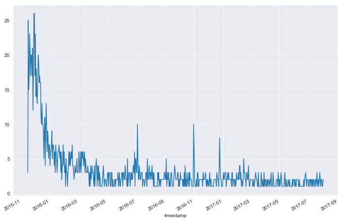

```python
twitter_archive_master["timestamp"] = twitter_archive_master.timestamp.values.astype("datetime64[D]")
twitter_archive_master.groupby("timestamp").tweet_id.count().plot(figsize = (12,8))
```

在2015年末，发送推特最为频繁；

在2016年开始到2017年，发送推特的数量趋于稳定，偶尔有几天会有一个峰值。

##### 名字 name的分析

```
(0, 20)
```

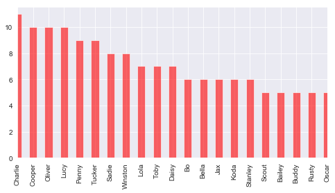

```python
twitter_archive_master.name.value_counts().plot(kind = 'bar',
                                                color = 'red',
                                                alpha = 0.6,
                                                figsize = (8,4))
plt.xlim([0,20])
```

将推特数据集中狗狗的名字进行计数，

可以发现最常用的狗狗名字是查理（Charlie）、库珀（Cooper）、奥利弗（Oliver）、露西（Lucy）

##### 推特来源 source 的分析

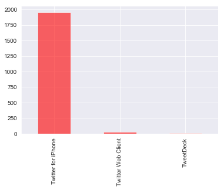

```python
twitter_archive_master.source.value_counts().plot(kind = 'bar',
                                                 color = 'red',
                                                 alpha = 0.6)
```

来源 source 表示了博主最常用的登陆方式是什么，根据上面的条形图，

可以明显看出博主在发送推特时，最喜欢用的方式是使用iphone上手机端的twitter应用软件( Twitter for iPhone)，

其次，博主也曾经用过网页版客户端 (Twitter Web Client) 和推特桌面版（TweetDesk）

##### 地位 stage的分析

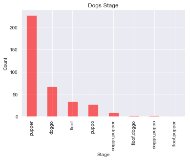

```python
#create bar chart for stage
twitter_archive_master.stage.value_counts().plot(kind = 'bar',
                                                 title = 'Dogs Stage',
                                                 color = 'red',
                                                 alpha = 0.6)
plt.xlabel('Stage')
plt.ylabel('Count')
```

https://github.com/Angelicahui/Data-Wrangling/blob/master/67627cea-cb12-4928-a1b0-f1ec5905ee91.png

##### 评分中分子与分母 rating_numerator & rating_denominator的相关分析

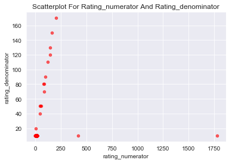

```python
#create scatterplot for rating_numerator and rating_denominator
twitter_archive_master.plot(x = "rating_numerator",y = "rating_denominator",
                            kind = "scatter", title = "Scatterplot For Rating_numerator And Rating_denominator",
                            color = 'red', alpha = 0.6);
```

从上图中可以看出，博主给狗狗们的打分，分子经常超过分母，有两个异常值

```python
#outliers in the scatterplot
twitter_archive_master.query("rating_numerator > 250")
```

|  | tweet_id | timestamp | source | text | expanded_urls | rating_numerator | rating_denominator | name | doggo | floofer | ... | p1_conf | p1_dog | p2 | p2_conf | p2_dog | p3 | p3_conf | p3_dog | retweet_count | favorite_count |
| --- | --- | --- | --- | --- | --- | --- | --- | --- | --- | --- | --- | --- | --- | --- | --- | --- | --- | --- | --- | --- | --- |
| 726 | 749981277374128128 | 2016-07-04 | TweetDeck | This is Atticus. He's quite simply America af.... | https://twitter.com/dog_rates/status/749981277... | 1776.0 | 10.0 | Atticus | None | None | ... | 0.533941 | False | sunglasses | 0.080822 | False | sunglass | 0.050776 | False | 2769 | 5594 |
| 1718 | 670842764863651840 | 2015-11-29 | Twitter for iPhone | After so many requests... here you go.\n\nGood... | https://twitter.com/dog_rates/status/670842764... | 420.0 | 10.0 | NaN | None | None | ... | 0.096063 | False | accordion | 0.094075 | False | drumstick | 0.061113 | False | 9509 | 25673 |

2 rows × 26 columns

这两个在散点图中的异常值，分别是编号 726 和编号 1718，分母都是10，分子分别为1776 和 420

##### 转发量与喜爱量 retweet_count and favorite_count的相关分析

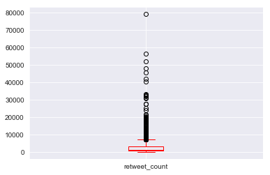

```python
#retweet_count analysis
twitter_archive_master.retweet_count.plot(kind  = "box", color = "red")
```

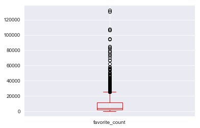

```python
#favorite_count analysis
twitter_archive_master.favorite_count.plot(kind  = "box", color = "red")
```

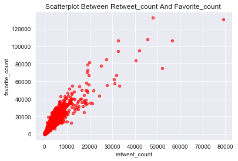

```python
#create scatterplot for retweet_count and favorite_count
twitter_archive_master.plot(x = "retweet_count",y = "favorite_count",
                            kind = "scatter", title = "Scatterplot Between Retweet_count And Favorite_count ",
                            color = "red", alpha = 0.6);
```

retweet_count 转发量与 favorite_count 点赞量成正比关系, 被人点赞更多的推特，也有更多的转发量